# R Notebook

# GLMs

### Ya hemos visto los casos binomial y gaussiano, atenderemos a los casos multinomial, gamma y binomial negativa.

# GlM Binomial negativa: sirve para variables de conteo

Cargamos el dataset de cangrejos con satélites

Each female horseshoe crab in the study had a male crab attached to her in her nest. The study investigated factors that affect whether the female crab had any other males, called satellites, residing near her. Explanatory variables that are thought to affect this included the female crab’s color (C), spine condition (S) (condicion de la columna vertebral), weight (Wt), and carapace width (tamaño del caparazón)(W). The response outcome for each female crab is her number of satellites (Sa). There are 173 females in this study

Se quiere explicar el número de satélites del cangrejo en función de los atributos descritos, como es una variable de conteo al ser un entero no negativo, el glm binomial negativo es el que mejor se adapta

```r
rm(list=ls())
```

```r
url <- 'https://newonlinecourses.science.psu.edu/stat504/sites/onlinecourses.science.psu.edu.stat504/files/lesson07/crab/index.txt'
df <- read.csv(url,header= F,sep = '\t')
crabs_data <- read.table(url)
colnames(crabs_data) <- c("Obs","C","S","W","Wt","Sa")
head(crabs_data)
```

|  | Obs | C | S | W | Wt | Sa |
| --- | --- | --- | --- | --- | --- | --- |
| 1 | 1 | 2 | 3 | 28.3 | 3.05 | 8 |
| 2 | 2 | 3 | 3 | 26.0 | 2.60 | 4 |
| 3 | 3 | 3 | 3 | 25.6 | 2.15 | 0 |
| 4 | 4 | 4 | 2 | 21.0 | 1.85 | 0 |
| 5 | 5 | 2 | 3 | 29.0 | 3.00 | 1 |
| 6 | 6 | 1 | 2 | 25.0 | 2.30 | 3 |

C -> Crabs color. S -> Condición de la columa. W -> Tamaño del caparazón. Wt -> Peso del cangrejo. Sa -> Número de Satélites.

```r
#Verificamos que no hay valores nulos.
sapply(crabs_data, function(x) sum(is.na(x)))
```

```
Obs   C   S   W  Wt  Sa
  0   0   0   0   0   0
```

```r
crabs_data$C<-as.factor(crabs_data$C)
crabs_data$S<-as.factor(crabs_data$S)
str(crabs_data)
```

```
'data.frame':   173 obs. of  6 variables:
 $ Obs: int  1 2 3 4 5 6 7 8 9 10 ...
 $ C  : Factor w/ 4 levels "1","2","3","4": 2 3 3 4 2 1 4 2 2 2 ...
 $ S  : Factor w/ 3 levels "1","2","3": 3 3 3 2 3 2 3 3 1 3 ...
 $ W  : num  28.3 26 25.6 21 29 25 26.2 24.9 25.7 27.5 ...
 $ Wt : num  3.05 2.6 2.15 1.85 3 2.3 1.3 2.1 2 3.15 ...
 $ Sa : int  8 4 0 0 1 3 0 0 8 6 ...
```

```r
dim(crabs_data)
```

```
[1] 173   6
```

```r
#Eliminamos la columna número de observación por no ser relevante.
crabs_data<-crabs_data[,-1]   #lo dejo comentado por si lo vuelvo a ejecutar no eliminar sucesivas columnas.
str(crabs_data)
```

```
'data.frame':   173 obs. of  5 variables:
 $ C : Factor w/ 4 levels "1","2","3","4": 2 3 3 4 2 1 4 2 2 2 ...
 $ S : Factor w/ 3 levels "1","2","3": 3 3 3 2 3 2 3 3 1 3 ...
 $ W : num  28.3 26 25.6 21 29 25 26.2 24.9 25.7 27.5 ...
 $ Wt: num  3.05 2.6 2.15 1.85 3 2.3 1.3 2.1 2 3.15 ...
 $ Sa: int  8 4 0 0 1 3 0 0 8 6 ...
```

```r
crabs_data
```

| C | S | W | Wt | Sa |
| --- | --- | --- | --- | --- |
| 2 | 3 | 28.3 | 3.05 | 8 |
| 3 | 3 | 26.0 | 2.60 | 4 |
| 3 | 3 | 25.6 | 2.15 | 0 |
| 4 | 2 | 21.0 | 1.85 | 0 |
| 2 | 3 | 29.0 | 3.00 | 1 |
| 1 | 2 | 25.0 | 2.30 | 3 |
| 4 | 3 | 26.2 | 1.30 | 0 |
| 2 | 3 | 24.9 | 2.10 | 0 |
| 2 | 1 | 25.7 | 2.00 | 8 |
| 2 | 3 | 27.5 | 3.15 | 6 |

[output cut: 163 more lines]

Hechamos un vistazo rápido a la variable Sa

```r
mean(crabs_data$Sa)
```

```
[1] 2.919075
```

```r
sd(crabs_data$Sa)
```

```
[1] 3.148336
```

Entrenamos el modelo que supone que todos los cangrejos tienen los mismos satélites

```r
library(MASS)
```

```r
#glm.nb -> Fit a Negative Binomial Generalized Linear Model
model <- glm.nb(Sa~1, data = crabs_data)
summary(model)
```

```
Call:
glm.nb(formula = Sa ~ 1, data = crabs_data, init.theta = 0.7577590381,
    link = log)

Deviance Residuals:
    Min       1Q   Median       3Q      Max
-1.5472  -1.5472  -0.2720   0.4659   1.7999

Coefficients:
            Estimate Std. Error z value Pr(>|z|)
(Intercept)  1.07127    0.09802   10.93   <2e-16 ***
---
Signif. codes:  0 ‘***’ 0.001 ‘**’ 0.01 ‘*’ 0.05 ‘.’ 0.1 ‘ ’ 1

(Dispersion parameter for Negative Binomial(0.7578) family taken to be 1)

    Null deviance: 192.93  on 172  degrees of freedom
Residual deviance: 192.93  on 172  degrees of freedom
AIC: 771.41

Number of Fisher Scoring iterations: 1

              Theta:  0.758
          Std. Err.:  0.126

 2 x log-likelihood:  -767.409
```

```r
model$fitted
```

[output not shown]

```r
model_2 <- glm.nb(Sa~W, data = crabs_data)
summary(model_2)
```

```
Call:
glm.nb(formula = Sa ~ W, data = crabs_data, init.theta = 0.90456808,
    link = log)

Deviance Residuals:
    Min       1Q   Median       3Q      Max
-1.7798  -1.4110  -0.2502   0.4770   2.0177

Coefficients:
            Estimate Std. Error z value Pr(>|z|)
(Intercept) -4.05251    1.17143  -3.459 0.000541 ***
W            0.19207    0.04406   4.360  1.3e-05 ***
---
Signif. codes:  0 ‘***’ 0.001 ‘**’ 0.01 ‘*’ 0.05 ‘.’ 0.1 ‘ ’ 1

(Dispersion parameter for Negative Binomial(0.9046) family taken to be 1)

    Null deviance: 213.05  on 172  degrees of freedom
Residual deviance: 195.81  on 171  degrees of freedom
AIC: 757.29

Number of Fisher Scoring iterations: 1

              Theta:  0.905
          Std. Err.:  0.161

 2 x log-likelihood:  -751.291
```

Observamos valores predichos frente a valor real

```r
head(data.frame(crabs_data,pred=model_2$fitted),20)
```

|  | C | S | W | Wt | Sa | pred |
| --- | --- | --- | --- | --- | --- | --- |
| 1 | 2 | 3 | 28.3 | 3.05 | 8 | 3.9874908 |
| 2 | 3 | 3 | 26.0 | 2.60 | 4 | 2.5635519 |
| 3 | 3 | 3 | 25.6 | 2.15 | 0 | 2.3739719 |
| 4 | 4 | 2 | 21.0 | 1.85 | 0 | 0.9812065 |
| 5 | 2 | 3 | 29.0 | 3.00 | 1 | 4.5613262 |
| 6 | 1 | 2 | 25.0 | 2.30 | 3 | 2.1155620 |
| 7 | 4 | 3 | 26.2 | 1.30 | 0 | 2.6639457 |
| 8 | 2 | 3 | 24.9 | 2.10 | 0 | 2.0753155 |
| 9 | 2 | 1 | 25.7 | 2.00 | 8 | 2.4200102 |
| 10 | 2 | 3 | 27.5 | 3.15 | 6 | 3.4195316 |

[output cut: 10 more lines]

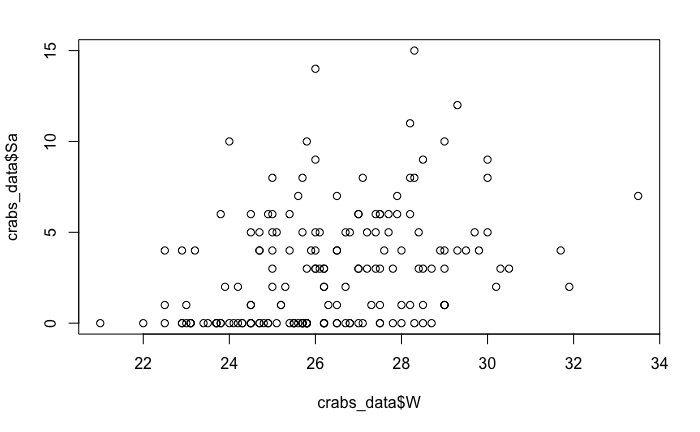

```r
plot(crabs_data$W,crabs_data$Sa)
```

Vamos a hacer una predicción concreta.

```r
newdt <- data.frame(W=26.3)
predict(model_2, newdt,type="response")
```

```
       1
2.715608
```

Vamos a ver cual sería el mejor modelo utilizando AIC

```r
fit1 <- glm.nb(Sa~., data=crabs_data)
fit0 <- glm.nb(Sa~1, data=crabs_data)
step <-stepAIC(fit0,direction="forward",scope=list(upper=fit1,lower=fit0))
```

```
Start:  AIC=769.41
Sa ~ 1

       Df    AIC
+ Wt    1 752.64
+ W     1 755.29
<none>    769.41
+ C     3 770.30
+ S     2 770.96

Step:  AIC=752.64
Sa ~ Wt

       Df    AIC
<none>    752.64
+ W     1 754.57
+ C     3 755.93
+ S     2 756.11
```

C -> Crabs color. S -> Condición de la columa. W -> Tamaño del caparazón. Wt -> Peso del cangrejo. Sa -> Número de Satélites.

```r
step$anova
```

```
Stepwise Model Path
Analysis of Deviance Table

Initial Model:
Sa ~ 1

Final Model:
Sa ~ Wt


  Step Df Deviance Resid. Df Resid. Dev      AIC
1                        172   192.9300 769.4092
2 + Wt  1 3.234081       171   196.1641 752.6430
```

```r
summary(step)
```

```
Call:
glm.nb(formula = Sa ~ Wt, data = crabs_data, init.theta = 0.9310998547,
    link = log)

Deviance Residuals:
    Min       1Q   Median       3Q      Max
-1.8393  -1.4123  -0.3246   0.4747   2.1278

Coefficients:
            Estimate Std. Error z value Pr(>|z|)
(Intercept)  -0.8637     0.4046  -2.135   0.0328 *
Wt            0.7599     0.1578   4.817 1.46e-06 ***
---
Signif. codes:  0 ‘***’ 0.001 ‘**’ 0.01 ‘*’ 0.05 ‘.’ 0.1 ‘ ’ 1

(Dispersion parameter for Negative Binomial(0.9311) family taken to be 1)

    Null deviance: 216.44  on 172  degrees of freedom
Residual deviance: 196.16  on 171  degrees of freedom
AIC: 754.64

Number of Fisher Scoring iterations: 1

              Theta:  0.931
          Std. Err.:  0.168

 2 x log-likelihood:  -748.643
```

```r
mod <- glm.nb(formula = Sa ~ Wt , data = crabs_data, init.theta = 0.931, link = log)
summary(mod)
```

```
Call:
glm.nb(formula = Sa ~ Wt, data = crabs_data, init.theta = 0.9311002517,
    link = log)

Deviance Residuals:
    Min       1Q   Median       3Q      Max
-1.8393  -1.4123  -0.3246   0.4747   2.1278

Coefficients:
            Estimate Std. Error z value Pr(>|z|)
(Intercept)  -0.8637     0.4046  -2.135   0.0328 *
Wt            0.7599     0.1578   4.817 1.46e-06 ***
---
Signif. codes:  0 ‘***’ 0.001 ‘**’ 0.01 ‘*’ 0.05 ‘.’ 0.1 ‘ ’ 1

(Dispersion parameter for Negative Binomial(0.9311) family taken to be 1)

    Null deviance: 216.44  on 172  degrees of freedom
Residual deviance: 196.16  on 171  degrees of freedom
AIC: 754.64

Number of Fisher Scoring iterations: 1

              Theta:  0.931
          Std. Err.:  0.168

 2 x log-likelihood:  -748.643
```

```r
exp(mod$coefficients)
```

```
(Intercept)          Wt
  0.4216186   2.1379659
```

```r
data.frame(crabs_data,pred=round(mod$fitted,digits = 0))
```

|  | C | S | W | Wt | Sa | pred |
| --- | --- | --- | --- | --- | --- | --- |
| 1 | 2 | 3 | 28.3 | 3.05 | 8 | 4 |
| 2 | 3 | 3 | 26.0 | 2.60 | 4 | 3 |
| 3 | 3 | 3 | 25.6 | 2.15 | 0 | 2 |
| 4 | 4 | 2 | 21.0 | 1.85 | 0 | 2 |
| 5 | 2 | 3 | 29.0 | 3.00 | 1 | 4 |
| 6 | 1 | 2 | 25.0 | 2.30 | 3 | 2 |
| 7 | 4 | 3 | 26.2 | 1.30 | 0 | 1 |
| 8 | 2 | 3 | 24.9 | 2.10 | 0 | 2 |
| 9 | 2 | 1 | 25.7 | 2.00 | 8 | 2 |
| 10 | 2 | 3 | 27.5 | 3.15 | 6 | 5 |

[output cut: 163 more lines]

```r
confint(mod)
```

```
                 2.5 %      97.5 %
(Intercept) -1.7527697 0.007707786
Wt           0.4204854 1.113033155
```

## Vamos a probar con regresión lineal simple además para comparar.

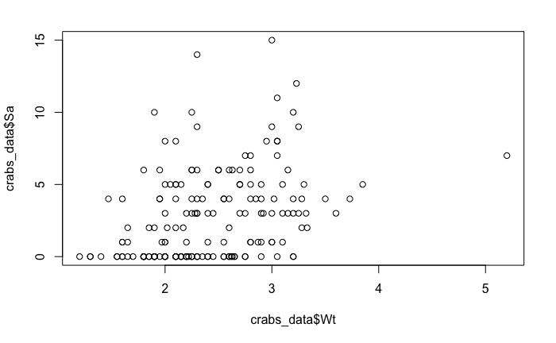

```r
plot(crabs_data$Wt,crabs_data$Sa)
```

```r
mod_lin<-lm(Sa~.,data = crabs_data)
summary(mod_lin)
```

```
Call:
lm(formula = Sa ~ ., data = crabs_data)

Residuals:
    Min      1Q  Median      3Q     Max
-4.5531 -2.1035 -0.6608  1.4525 11.1437

Coefficients:
            Estimate Std. Error t value Pr(>|t|)
(Intercept) -1.07096    4.72099  -0.227   0.8208
C2          -0.69742    0.96566  -0.722   0.4712
C3          -1.33263    1.06730  -1.249   0.2136
C4          -1.30946    1.17587  -1.114   0.2671
S2          -0.45289    0.95224  -0.476   0.6350
S3           0.06491    0.62504   0.104   0.9174
W            0.02258    0.23924   0.094   0.9249
Wt           1.75546    0.85759   2.047   0.0422 *
---
Signif. codes:  0 ‘***’ 0.001 ‘**’ 0.01 ‘*’ 0.05 ‘.’ 0.1 ‘ ’ 1

Residual standard error: 2.962 on 165 degrees of freedom
Multiple R-squared:  0.1511,    Adjusted R-squared:  0.1151
F-statistic: 4.196 on 7 and 165 DF,  p-value: 0.0002781
```

```r
mod_lin<-lm(Sa~Wt,data = crabs_data)
summary(mod_lin)
```

```
Call:
lm(formula = Sa ~ Wt, data = crabs_data)

Residuals:
    Min      1Q  Median      3Q     Max
-4.4554 -2.2398 -0.8299  1.6453 11.3573

Coefficients:
            Estimate Std. Error t value Pr(>|t|)
(Intercept)  -1.9899     0.9706  -2.050   0.0419 *
Wt            2.0142     0.3876   5.197 5.73e-07 ***
---
Signif. codes:  0 ‘***’ 0.001 ‘**’ 0.01 ‘*’ 0.05 ‘.’ 0.1 ‘ ’ 1

Residual standard error: 2.934 on 171 degrees of freedom
Multiple R-squared:  0.1364,    Adjusted R-squared:  0.1313
F-statistic:    27 on 1 and 171 DF,  p-value: 5.73e-07
```

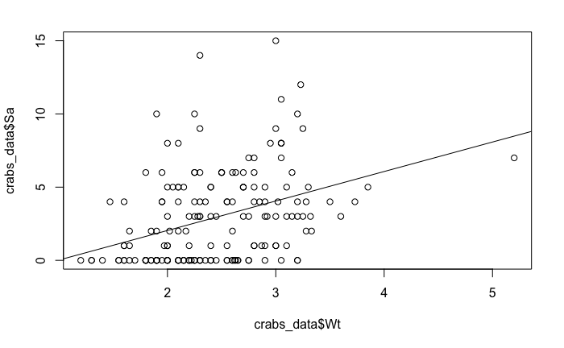

```r
plot(crabs_data$Wt,crabs_data$Sa)
abline(mod_lin)
```

```r
mod_lin$fitted.values
```

[output not shown]

```r
data.frame(crabs_data,pred=round(mod_lin$fitted,digits = 0))
```

|  | C | S | W | Wt | Sa | pred |
| --- | --- | --- | --- | --- | --- | --- |
| 1 | 2 | 3 | 28.3 | 3.05 | 8 | 4 |
| 2 | 3 | 3 | 26.0 | 2.60 | 4 | 3 |
| 3 | 3 | 3 | 25.6 | 2.15 | 0 | 2 |
| 4 | 4 | 2 | 21.0 | 1.85 | 0 | 2 |
| 5 | 2 | 3 | 29.0 | 3.00 | 1 | 4 |
| 6 | 1 | 2 | 25.0 | 2.30 | 3 | 3 |
| 7 | 4 | 3 | 26.2 | 1.30 | 0 | 1 |
| 8 | 2 | 3 | 24.9 | 2.10 | 0 | 2 |
| 9 | 2 | 1 | 25.7 | 2.00 | 8 | 2 |
| 10 | 2 | 3 | 27.5 | 3.15 | 6 | 4 |

[output cut: 163 more lines]

# GLM Gamma: regresión Gamma

La distribución Gamma sirve para hacer regresión sobre datos que toman valores positivos y están sesgados hacia la derecha. Funciona bien y puede aproximar distribuciones como la lognormal sin problema dada su flexibilidad. Un ejemplo de este tipo de datos suele ser el ROI en forma de ratio.

Hay tres tipos de función link posibles para la gamma: “identity”, “log” e “inverse”.

Vemos un ejemplo de regresión Gamma:

```r
install.packages("faraway")
library(faraway)
```

```r
data(wafer)
help(wafer)
```

```r
head(wafer)
```

|  | x1 | x2 | x3 | x4 | resist |
| --- | --- | --- | --- | --- | --- |
| 1 | - | - | - | - | 193.4 |
| 2 | + | - | - | - | 247.6 |
| 3 | - | + | - | - | 168.2 |
| 4 | + | + | - | - | 205.0 |
| 5 | - | - | + | - | 303.4 |
| 6 | + | - | + | - | 339.9 |

Vemos que los datos están sesgados hacia la derecha: https://www.google.es/search?q=valores+sesgados&source=lnms&tbm=isch&sa=X&ved=0ahUKEwi9i_T6443fAhUiSxUIHY_MAUUQ_AUIDigB&biw=1589&bih=814#imgrc=2tFq4pN8NuwUoM:

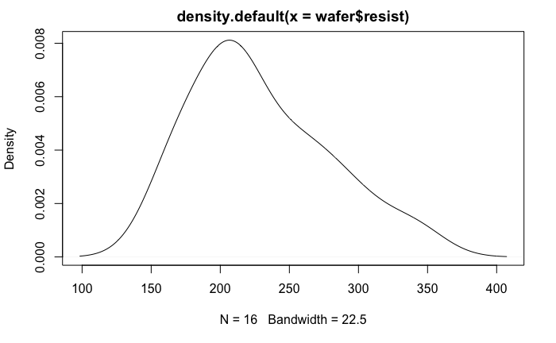

```r
#observamos que toma valores positivos la variable objetivo
plot(density(wafer$resist))
```

```r
summary(wafer)
```

```
 x1    x2    x3    x4        resist
 -:8   -:8   -:8   -:8   Min.   :165.7
 +:8   +:8   +:8   +:8   1st Qu.:201.0
                         Median :214.2
                         Mean   :229.3
                         3rd Qu.:259.3
                         Max.   :339.9
```

Lo habitual para hacer regresión sobre una distirbución sesgada hacia la derecha es tomar logaritmos:

```r
res.lm.logY <- lm(log(resist) ~ x1 + x2 + x3 + x4, data = wafer)
summary(res.lm.logY)
```

```
Call:
lm(formula = log(resist) ~ x1 + x2 + x3 + x4, data = wafer)

Residuals:
     Min       1Q   Median       3Q      Max
-0.17572 -0.06222  0.01749  0.08765  0.10841

Coefficients:
            Estimate Std. Error t value Pr(>|t|)
(Intercept)  5.44048    0.05982  90.948  < 2e-16 ***
x1+          0.12277    0.05350   2.295 0.042432 *
x2+         -0.29986    0.05350  -5.604 0.000159 ***
x3+          0.17844    0.05350   3.335 0.006652 **
x4+         -0.05615    0.05350  -1.049 0.316515
---
Signif. codes:  0 ‘***’ 0.001 ‘**’ 0.01 ‘*’ 0.05 ‘.’ 0.1 ‘ ’ 1

Residual standard error: 0.107 on 11 degrees of freedom
Multiple R-squared:  0.8164,    Adjusted R-squared:  0.7496
F-statistic: 12.22 on 4 and 11 DF,  p-value: 0.0004915
```

Probamos un modelo con glm gamma para ver que son equivalentes:

```r
res.glm.Gamma.log <- glm(formula = resist ~ x1 + x2 + x3 + x4,
                         family  = Gamma(link = "log"),
                         data    = wafer)
summary(res.glm.Gamma.log)
```

```
Call:
glm(formula = resist ~ x1 + x2 + x3 + x4, family = Gamma(link = "log"),
    data = wafer)

Deviance Residuals:
     Min        1Q    Median        3Q       Max
-0.17548  -0.06486   0.01423   0.08399   0.10898

Coefficients:
            Estimate Std. Error t value Pr(>|t|)
(Intercept)  5.44552    0.05856  92.983  < 2e-16 ***
x1+          0.12115    0.05238   2.313 0.041090 *
x2+         -0.30049    0.05238  -5.736 0.000131 ***
x3+          0.17979    0.05238   3.432 0.005601 **
x4+         -0.05757    0.05238  -1.099 0.295248
---
Signif. codes:  0 ‘***’ 0.001 ‘**’ 0.01 ‘*’ 0.05 ‘.’ 0.1 ‘ ’ 1

(Dispersion parameter for Gamma family taken to be 0.01097542)

    Null deviance: 0.69784  on 15  degrees of freedom
Residual deviance: 0.12418  on 11  degrees of freedom
AIC: 152.91

Number of Fisher Scoring iterations: 4
```

Pintamos los residuos y vemos que son iguales

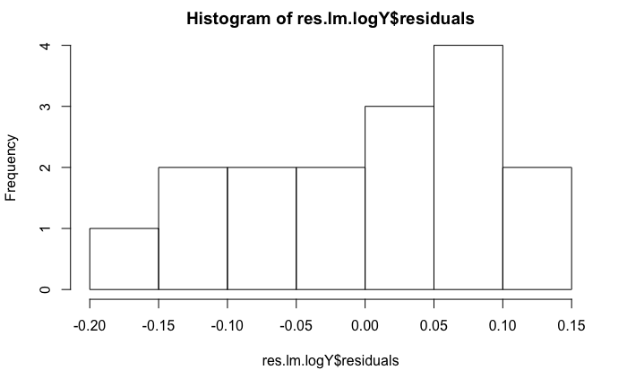

```r
hist(res.lm.logY$residuals)
```

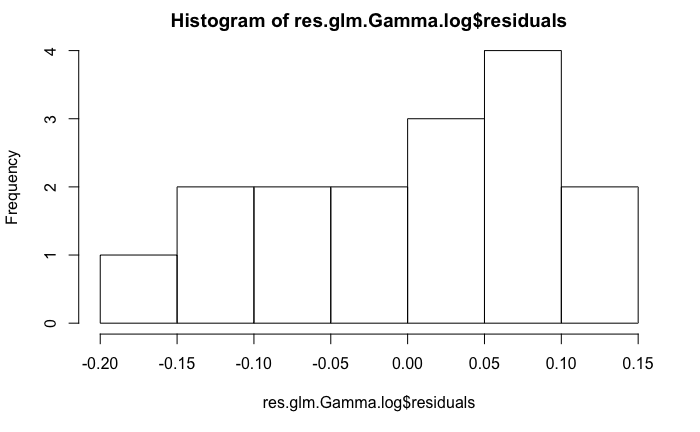

```r
hist(res.glm.Gamma.log$residuals)
```

Probamos la versión con link “identity”, tiene mayor AIC

```r
res.glm.Gamma.identity <- glm(formula = resist ~ x1 + x2 + x3 + x4,
                              family  = Gamma(link = "identity"),
                              data    = wafer)
summary(res.glm.Gamma.identity)
```

```
Call:
glm(formula = resist ~ x1 + x2 + x3 + x4, family = Gamma(link = "identity"),
    data = wafer)

Deviance Residuals:
      Min         1Q     Median         3Q        Max
-0.190394  -0.066533   0.005538   0.091549   0.126838

Coefficients:
            Estimate Std. Error t value Pr(>|t|)
(Intercept)   235.43      14.21  16.572 3.97e-09 ***
x1+            27.83      12.24   2.274 0.044017 *
x2+           -65.74      12.68  -5.184 0.000302 ***
x3+            36.94      12.32   2.999 0.012102 *
x4+           -11.88      12.15  -0.978 0.349294
---
Signif. codes:  0 ‘***’ 0.001 ‘**’ 0.01 ‘*’ 0.05 ‘.’ 0.1 ‘ ’ 1

(Dispersion parameter for Gamma family taken to be 0.0124071)

    Null deviance: 0.69784  on 15  degrees of freedom
Residual deviance: 0.14009  on 11  degrees of freedom
AIC: 154.84

Number of Fisher Scoring iterations: 6
```

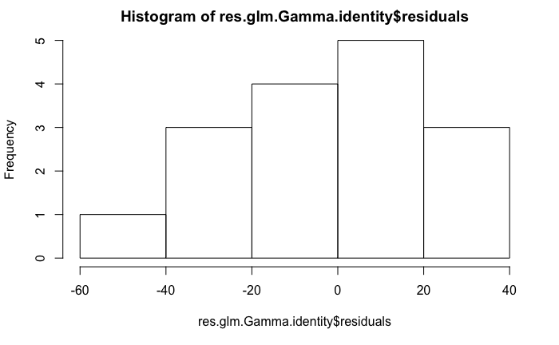

```r
hist(res.glm.Gamma.identity$residuals)
```

Probamos la versión con link “inverse”“, tiene menor AIC que las dos anteriores, parece preferible.

```r
res.glm.Gamma.inverse <- glm(formula = resist ~ x1 + x2 + x3 + x4,
                              family  = Gamma(link = "inverse"),
                              data    = wafer)
summary(res.glm.Gamma.inverse)
```

```
Call:
glm(formula = resist ~ x1 + x2 + x3 + x4, family = Gamma(link = "inverse"),
    data = wafer)

Deviance Residuals:
      Min         1Q     Median         3Q        Max
-0.165749  -0.051452   0.003529   0.071213   0.113935

Coefficients:
              Estimate Std. Error t value Pr(>|t|)
(Intercept)  0.0043603  0.0002471  17.644 2.04e-09 ***
x1+         -0.0004756  0.0002180  -2.181 0.051752 .
x2+          0.0013445  0.0002272   5.918 0.000101 ***
x3+         -0.0008148  0.0002208  -3.691 0.003560 **
x4+          0.0002662  0.0002170   1.227 0.245574
---
Signif. codes:  0 ‘***’ 0.001 ‘**’ 0.01 ‘*’ 0.05 ‘.’ 0.1 ‘ ’ 1

(Dispersion parameter for Gamma family taken to be 0.01022894)

    Null deviance: 0.69784  on 15  degrees of freedom
Residual deviance: 0.11540  on 11  degrees of freedom
AIC: 151.73

Number of Fisher Scoring iterations: 4
```

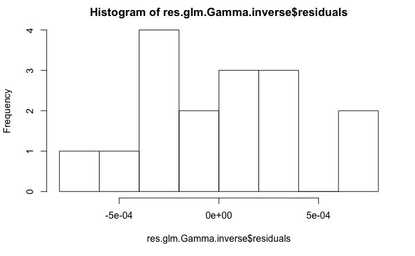

```r
hist(res.glm.Gamma.inverse$residuals)
```

Buscamos el modelo Gamma mejor dentro de las posibilidades usando el criterio AIC

```r
fit1 <- glm(resist~., data=wafer, family=Gamma(link = "inverse"))
fit0 <- glm(resist~1, data=wafer, family=Gamma(link = "inverse"))
library(MASS)
step <-stepAIC(fit0,direction="forward",scope=list(upper=fit1,lower=fit0))
```

```
Start:  AIC=172.62
resist ~ 1

       Df Deviance    AIC
+ x2    1  0.32177 166.88
+ x3    1  0.55260 171.63
<none>     0.69784 172.62
+ x1    1  0.64725 173.58
+ x4    1  0.68186 174.29

Step:  AIC=162.17
resist ~ x2

       Df Deviance    AIC
+ x3    1  0.17980 157.85
+ x1    1  0.27233 161.97
<none>     0.32177 162.17
+ x4    1  0.30615 163.48

Step:  AIC=154.84
resist ~ x2 + x3

       Df Deviance    AIC
+ x1    1  0.13082 153.21
<none>     0.17980 154.84
+ x4    1  0.16433 155.69

Step:  AIC=151.74
resist ~ x2 + x3 + x1

       Df Deviance    AIC
<none>     0.13082 151.74
+ x4    1  0.11540 152.30
```

```r
step$anova
```

```
Stepwise Model Path
Analysis of Deviance Table

Initial Model:
resist ~ 1

Final Model:
resist ~ x2 + x3 + x1


  Step Df   Deviance Resid. Df Resid. Dev      AIC
1                           15  0.6978368 172.6234
2 + x2  1 0.37606518        14  0.3217716 162.1744
3 + x3  1 0.14197611        13  0.1797955 154.8384
4 + x1  1 0.04897506        12  0.1308205 151.7423
```

```r
summary(step)
```

```
Call:
glm(formula = resist ~ x2 + x3 + x1, family = Gamma(link = "inverse"),
    data = wafer)

Deviance Residuals:
      Min         1Q     Median         3Q        Max
-0.159576  -0.053889  -0.009359   0.085361   0.130201

Coefficients:
              Estimate Std. Error t value Pr(>|t|)
(Intercept)  0.0044894  0.0002301  19.513 1.86e-10 ***
x2+          0.0013457  0.0002322   5.796 8.53e-05 ***
x3+         -0.0008156  0.0002256  -3.615  0.00355 **
x1+         -0.0004761  0.0002228  -2.136  0.05393 .
---
Signif. codes:  0 ‘***’ 0.001 ‘**’ 0.01 ‘*’ 0.05 ‘.’ 0.1 ‘ ’ 1

(Dispersion parameter for Gamma family taken to be 0.01067467)

    Null deviance: 0.69784  on 15  degrees of freedom
Residual deviance: 0.13082  on 12  degrees of freedom
AIC: 151.74

Number of Fisher Scoring iterations: 4
```

```r
step$fitted.values
```

```
       1        2        3        4        5        6        7        8        9       10       11       12
222.7490 249.1729 171.3767 186.6014 272.2010 312.7271 199.2232 220.0987 222.7490 249.1729 171.3767 186.6014
      13       14       15       16
272.2010 312.7271 199.2232 220.0987
```

```r
head(data.frame(wafer,step$fitted.values),16)
```

|  | x1 | x2 | x3 | x4 | resist | step.fitted.values |
| --- | --- | --- | --- | --- | --- | --- |
| 1 | - | - | - | - | 193.4 | 222.7490 |
| 2 | + | - | - | - | 247.6 | 249.1729 |
| 3 | - | + | - | - | 168.2 | 171.3767 |
| 4 | + | + | - | - | 205.0 | 186.6014 |
| 5 | - | - | + | - | 303.4 | 272.2010 |
| 6 | + | - | + | - | 339.9 | 312.7271 |
| 7 | - | + | + | - | 226.3 | 199.2232 |
| 8 | + | + | + | - | 208.3 | 220.0987 |
| 9 | - | - | - | + | 220.0 | 222.7490 |
| 10 | + | - | - | + | 256.4 | 249.1729 |

[output cut: 6 more lines]

# GLM Multinomial: clasificación múltiple

El GLM Multinomial se aplica cuando tenemos que realizar una clasificación con 3 categorías o más. Cargamos el dataset iris, que tiene atributos de 3 flores y una columna con el valor de la clase.

```r
#install.packages(c("glmnet","ISLR"))
library(glmnet,help=T)
```

```r
help("glmnet")
library(glmnet)
library("foreign")
data(iris)
dim(iris)
```

```
[1] 150   5
```

```r
iris
```

| Sepal.Length | Sepal.Width | Petal.Length | Petal.Width | Species |
| --- | --- | --- | --- | --- |
| 5.1 | 3.5 | 1.4 | 0.2 | setosa |
| 4.9 | 3.0 | 1.4 | 0.2 | setosa |
| 4.7 | 3.2 | 1.3 | 0.2 | setosa |
| 4.6 | 3.1 | 1.5 | 0.2 | setosa |
| 5.0 | 3.6 | 1.4 | 0.2 | setosa |
| 5.4 | 3.9 | 1.7 | 0.4 | setosa |
| 4.6 | 3.4 | 1.4 | 0.3 | setosa |
| 5.0 | 3.4 | 1.5 | 0.2 | setosa |
| 4.4 | 2.9 | 1.4 | 0.2 | setosa |
| 4.9 | 3.1 | 1.5 | 0.1 | setosa |

[output cut: 140 more lines]

```r
str(iris)
```

```
'data.frame':   150 obs. of  5 variables:
 $ Sepal.Length: num  5.1 4.9 4.7 4.6 5 5.4 4.6 5 4.4 4.9 ...
 $ Sepal.Width : num  3.5 3 3.2 3.1 3.6 3.9 3.4 3.4 2.9 3.1 ...
 $ Petal.Length: num  1.4 1.4 1.3 1.5 1.4 1.7 1.4 1.5 1.4 1.5 ...
 $ Petal.Width : num  0.2 0.2 0.2 0.2 0.2 0.4 0.3 0.2 0.2 0.1 ...
 $ Species     : Factor w/ 3 levels "setosa","versicolor",..: 1 1 1 1 1 1 1 1 1 1 ...
```

```r
X <- as.matrix(subset(iris, select=- Species ))
y <- iris$Species
head(X)
```

```
  Sepal.Length Sepal.Width Petal.Length Petal.Width
1          5.1         3.5          1.4         0.2
2          4.9         3.0          1.4         0.2
3          4.7         3.2          1.3         0.2
4          4.6         3.1          1.5         0.2
5          5.0         3.6          1.4         0.2
6          5.4         3.9          1.7         0.4
```

```r
y
```

```
  [1] setosa     setosa     setosa     setosa     setosa     setosa     setosa     setosa     setosa
 [10] setosa     setosa     setosa     setosa     setosa     setosa     setosa     setosa     setosa
 [19] setosa     setosa     setosa     setosa     setosa     setosa     setosa     setosa     setosa
 [28] setosa     setosa     setosa     setosa     setosa     setosa     setosa     setosa     setosa
 [37] setosa     setosa     setosa     setosa     setosa     setosa     setosa     setosa     setosa
 [46] setosa     setosa     setosa     setosa     setosa     versicolor versicolor versicolor versicolor
 [55] versicolor versicolor versicolor versicolor versicolor versicolor versicolor versicolor versicolor
 [64] versicolor versicolor versicolor versicolor versicolor versicolor versicolor versicolor versicolor
 [73] versicolor versicolor versicolor versicolor versicolor versicolor versicolor versicolor versicolor
 [82] versicolor versicolor versicolor versicolor versicolor versicolor versicolor versicolor versicolor
 [91] versicolor versicolor versicolor versicolor versicolor versicolor versicolor versicolor versicolor
[100] versicolor virginica  virginica  virginica  virginica  virginica  virginica  virginica  virginica
[109] virginica  virginica  virginica  virginica  virginica  virginica  virginica  virginica  virginica
[118] virginica  virginica  virginica  virginica  virginica  virginica  virginica  virginica  virginica
[127] virginica  virginica  virginica  virginica  virginica  virginica  virginica  virginica  virginica
[136] virginica  virginica  virginica  virginica  virginica  virginica  virginica  virginica  virginica
[145] virginica  virginica  virginica  virginica  virginica  virginica
Levels: setosa versicolor virginica
```

```r
mod <- glmnet(X, y, alpha=0, family = "multinomial",type.multinomial="ungrouped")
summary(mod)
```

```
           Length Class  Mode
a0         300    -none- numeric
beta         3    -none- list
dfmat      300    -none- numeric
df         100    -none- numeric
dim          2    -none- numeric
lambda     100    -none- numeric
dev.ratio  100    -none- numeric
nulldev      1    -none- numeric
npasses      1    -none- numeric
jerr         1    -none- numeric
offset       1    -none- logical
classnames   3    -none- character
grouped      1    -none- logical
call         6    -none- call
nobs         1    -none- numeric
```

```r
print(mod)
```

```
Call:  glmnet(x = X, y = y, family = "multinomial", alpha = 0, type.multinomial = "ungrouped")

       Df       %Dev    Lambda
  [1,]  4 -1.213e-15 435.00000
  [2,]  4  2.204e-03 396.40000
  [3,]  4  2.419e-03 361.10000
  [4,]  4  2.653e-03 329.10000
  [5,]  4  2.911e-03 299.80000
  [6,]  4  3.193e-03 273.20000
  [7,]  4  3.503e-03 248.90000
  [8,]  4  3.843e-03 226.80000
  [9,]  4  4.215e-03 206.70000
 [10,]  4  4.623e-03 188.30000
 [11,]  4  5.070e-03 171.60000
 [12,]  4  5.560e-03 156.30000
```

[output cut: 88 more lines]

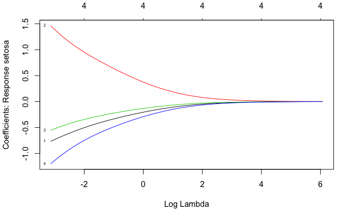

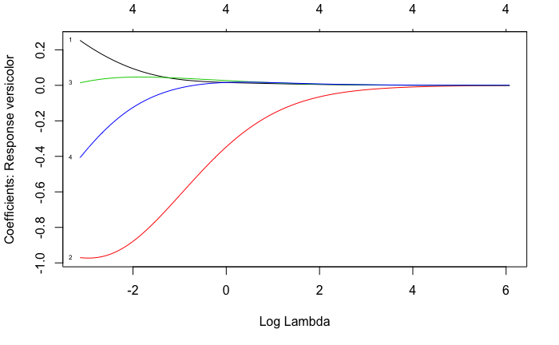

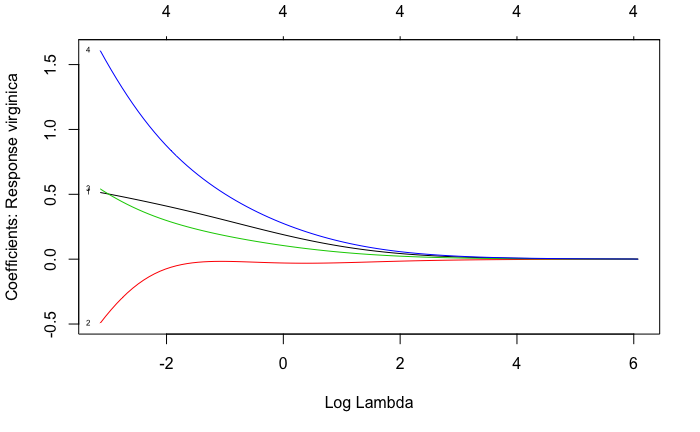

```r
plot(mod,xvar = "lambda", label = TRUE)
```

```r
coef(mod,s=0)
```

```
$setosa
5 x 1 sparse Matrix of class "dgCMatrix"
                      1
(Intercept)   3.2211944
Sepal.Length -0.7668679
Sepal.Width   1.4637684
Petal.Length -0.5552980
Petal.Width  -1.2000925

$versicolor
5 x 1 sparse Matrix of class "dgCMatrix"
                      1
(Intercept)   2.8350095
Sepal.Length  0.2530245
Sepal.Width  -0.9703178
Petal.Length  0.0139932
Petal.Width  -0.4077709

$virginica
5 x 1 sparse Matrix of class "dgCMatrix"
                      1
(Intercept)  -6.0562039
Sepal.Length  0.5138434
Sepal.Width  -0.4934506
Petal.Length  0.5413048
Petal.Width   1.6078634
```

```r
coef(mod,s=0.1)
```

```
$setosa
5 x 1 sparse Matrix of class "dgCMatrix"
                      1
(Intercept)   2.2351694
Sepal.Length -0.5655904
Sepal.Width   1.0661543
Petal.Length -0.3913370
Petal.Width  -0.8490486

$versicolor
5 x 1 sparse Matrix of class "dgCMatrix"
                       1
(Intercept)   2.71138271
Sepal.Length  0.12658270
Sepal.Width  -0.92954773
Petal.Length  0.04365765
Petal.Width  -0.18188314

$virginica
5 x 1 sparse Matrix of class "dgCMatrix"
                      1
(Intercept)  -4.9465521
Sepal.Length  0.4390077
Sepal.Width  -0.1366065
Petal.Length  0.3476793
Petal.Width   1.0309317
```

```r
coef(mod,s=0.23)
```

```
$setosa
5 x 1 sparse Matrix of class "dgCMatrix"
                      1
(Intercept)   1.5302384
Sepal.Length -0.4075871
Sepal.Width   0.7772292
Petal.Length -0.2744840
Petal.Width  -0.5996327

$versicolor
5 x 1 sparse Matrix of class "dgCMatrix"
                       1
(Intercept)   2.20447248
Sepal.Length  0.05400675
Sepal.Width  -0.75296251
Petal.Length  0.04518872
Petal.Width  -0.05362870

$virginica
5 x 1 sparse Matrix of class "dgCMatrix"
                       1
(Intercept)  -3.73471090
Sepal.Length  0.35358032
Sepal.Width  -0.02426669
Petal.Length  0.22929529
Petal.Width   0.65326144
```

Obtenemos las probabilidades de cada valor

```r
predict(mod,newx = X[1:2,],s=0,type = "response")
```

```
, , 1

     setosa versicolor    virginica
1 0.9393435 0.06013654 0.0005199507
2 0.8492914 0.14974043 0.0009681843
```

Calculamos el mejor modelo posible (parecido a stepAIC)

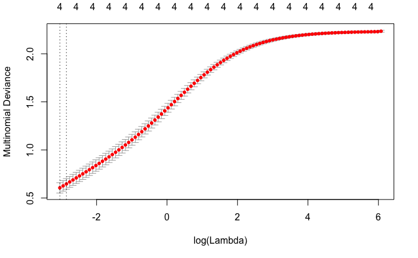

```r
cvfit <- cv.glmnet(X, y, alpha=0, family = "multinomial",type.multinomial="ungrouped")
plot(cvfit)
```

```r
coef(cvfit, s = "lambda.min")
```

```
$setosa
5 x 1 sparse Matrix of class "dgCMatrix"
                      1
(Intercept)   3.0988333
Sepal.Length -0.7423807
Sepal.Width   1.4125717
Petal.Length -0.5342076
Petal.Width  -1.1547633

$versicolor
5 x 1 sparse Matrix of class "dgCMatrix"
                       1
(Intercept)   2.83838658
Sepal.Length  0.23606631
Sepal.Width  -0.97233779
Petal.Length  0.01926372
Petal.Width  -0.37791120

$virginica
5 x 1 sparse Matrix of class "dgCMatrix"
                      1
(Intercept)  -5.9372198
Sepal.Length  0.5063144
Sepal.Width  -0.4402339
Petal.Length  0.5149439
Petal.Width   1.5326745
```